# Introducción a los GLM

07/05, 2020

## Formula (g)lm con interacciones

Supongamos que tenemos dos variables \(X_1\) categorica e \(X_2\) es continua

- \(C_0\) Intercepto
- \(C_1\) modificador de intercepto para nivel 1
- \(\beta_1\) pendiente de argumento 1

\[y = \beta_1X_1 + \beta_2X_2 + \beta_3X_1X_2 + C_0 + C_1\]

## Algunas especificaciones de un modelo lineal

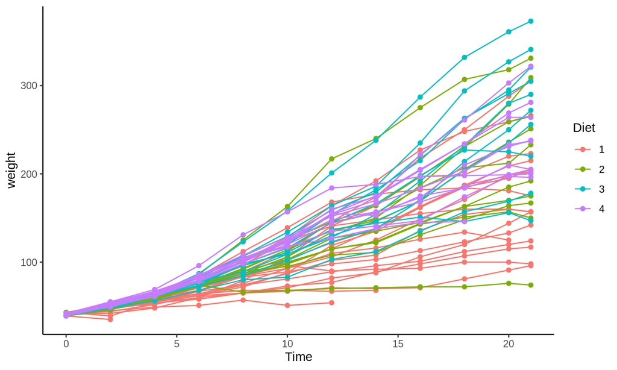

## Cambio intercepto pero no pendiente

```r
fit1 <- lm(weight ~ Time + Diet, data = ChickWeight)
```

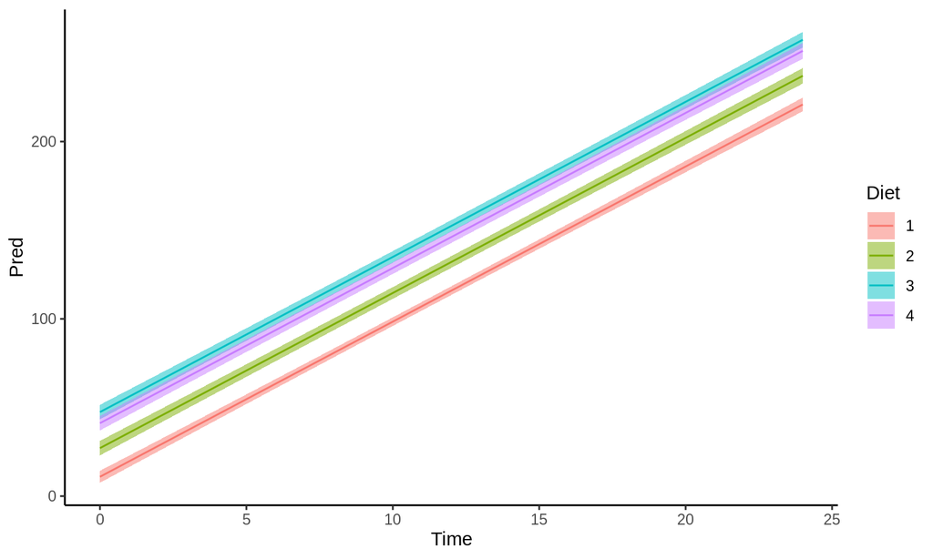

## Parametros

| term | estimate | std.error | statistic | p.value |
| --- | --- | --- | --- | --- |
| (Intercept) | 10.924391 | 3.3606567 | 3.250672 | 0.0012189 |
| Time | 8.750492 | 0.2218052 | 39.451248 | 0.0000000 |
| Diet2 | 16.166074 | 4.0858416 | 3.956608 | 0.0000856 |
| Diet3 | 36.499407 | 4.0858416 | 8.933143 | 0.0000000 |
| Diet4 | 30.233456 | 4.1074850 | 7.360576 | 0.0000000 |

## Calculemos

\[\small Weight = 8.75\times Time + 10.92 + \theta_216.17 + \theta_336.50 + \theta_430.23\]

| Time | 0 | 0 | 4 | 4 |
| --- | --- | --- | --- | --- |
| Diet | 1 | 4 | 1 | 4 |

```r
(8.75 * 0) + 10.92 + (0 * 16.17) + (0 * 36.5) + (0 * 30.23)
```

```
## [1] 10.92
```

```r
(8.75 * 0) + 10.92 + (0 * 16.17) + (0 * 36.5) + (1 * 30.23)
```

```
## [1] 41.15
```

```r
(8.75 * 4) + 10.92 + (0 * 16.17) + (0 * 36.5) + (0 * 30.23)
```

```
## [1] 45.92
```

```r
(8.75 * 4) + 10.92 + (0 * 16.17) + (0 * 36.5) + (1 * 30.23)
```

```
## [1] 76.15
```

## Cambio Pendiente pero no intercepto

```r
fit2 <- lm(weight ~ Time + Time:Diet, data = ChickWeight)
```

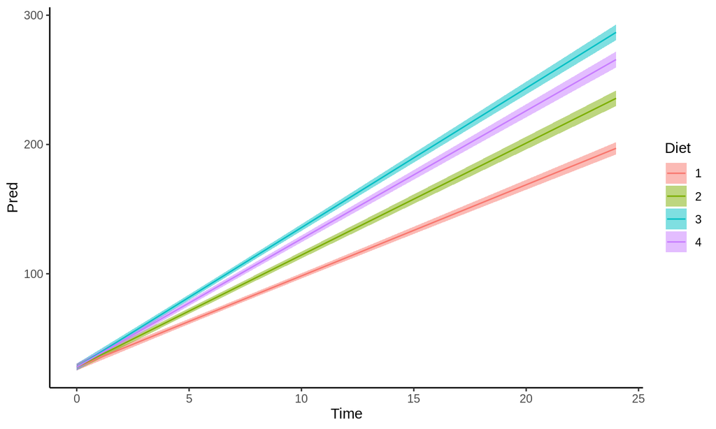

## Parametros

| term | estimate | std.error | statistic | p.value |
| --- | --- | --- | --- | --- |
| (Intercept) | 27.858834 | 2.6596172 | 10.474753 | 0e+00 |
| Time | 7.049161 | 0.2573403 | 27.392373 | 0e+00 |
| Time:Diet2 | 1.611209 | 0.3043700 | 5.293588 | 2e-07 |
| Time:Diet3 | 3.738317 | 0.3043700 | 12.282147 | 0e+00 |
| Time:Diet4 | 2.861438 | 0.3085932 | 9.272523 | 0e+00 |

## Calculemos

\[\small Weight = 7.05\times Time + Time \theta_2\times 1.61 + Time \theta_3\times 3.74 + Time \theta_4\times 2.86 + 27.86\]

- Nuevos datos

| Time | Diet |
| --- | --- |
| 3 | 1 |
| 4 | 4 |

```r
(7.05 * 3) + (3 * 0 * 1.61) + (3 * 0 * 3.74) + (3 * 0 * 2.86) + 27.86
```

```
## [1] 49.01
```

```r
(7.05 * 4) + (4 * 0 * 1.61) + (4 * 0 * 3.74) + (4 * 1 * 2.86) + 27.86
```

```
## [1] 67.5
```

## Cambio Pendiente e intercepto

```r
fit3 <- lm(weight ~ Time * Diet, data = ChickWeight)
```

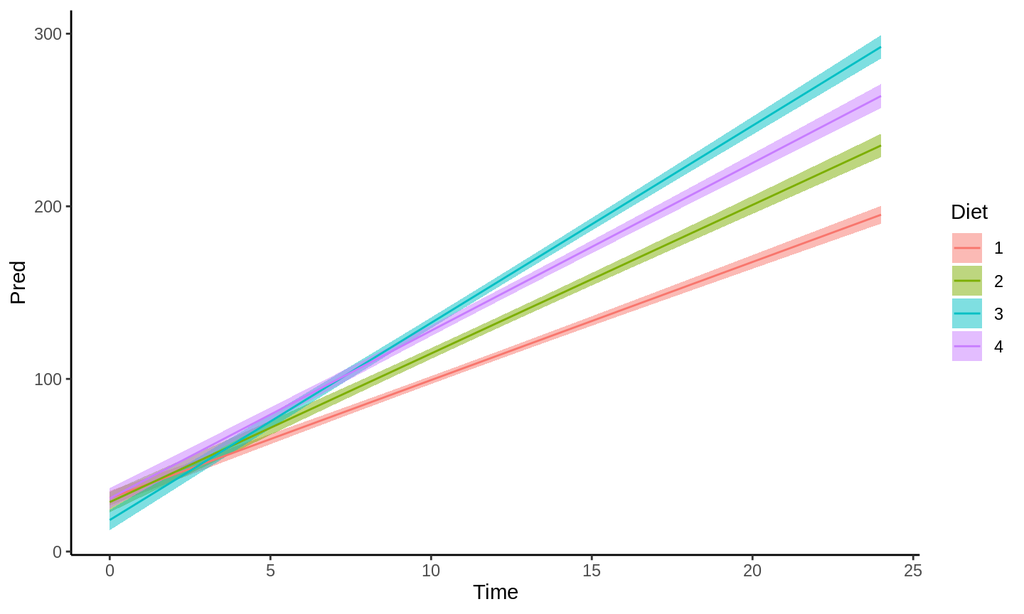

## Parametros

| term | estimate | std.error | statistic | p.value |
| --- | --- | --- | --- | --- |
| (Intercept) | 30.9309803 | 4.2468279 | 7.2833138 | 0.0000000 |
| Time | 6.8417972 | 0.3407938 | 20.0760630 | 0.0000000 |
| Diet2 | -2.2973848 | 7.2672309 | -0.3161293 | 0.7520201 |
| Diet3 | -12.6806551 | 7.2672309 | -1.7449088 | 0.0815397 |
| Diet4 | -0.1388608 | 7.2864589 | -0.0190574 | 0.9848020 |
| Time:Diet2 | 1.7673391 | 0.5716680 | 3.0915481 | 0.0020885 |
| Time:Diet3 | 4.5810738 | 0.5716680 | 8.0135216 | 0.0000000 |
| Time:Diet4 | 2.8725684 | 0.5781161 | 4.9688434 | 0.0000009 |

## Calculemos

\[\scriptsize Weight = 6.84\times Time + Time \theta_2\times 1.77 + Time \theta_3\times 4.58 + Time \theta_4\times 2.87 + 30.93 + -2.3\theta_2 + -12.7\theta_3 + -0.14\theta_4\]

| Time | Diet |
| --- | --- |
| 3 | 1 |
| 4 | 4 |

```r
(6.84 * 3) + (3 * 0 * 1.77) + (3 * 0 * 4.58) + (3 * 0 * 2.87) + 30.93 + (-2.3 * 0) +
    (-12.7 * 0) + (-0.14 * 0)
```

```
## [1] 51.45
```

```r
(6.84 * 4) + (4 * 0 * 1.77) + (4 * 0 * 4.58) + (4 * 1 * 2.87) + 30.93 + (-2.3 * 0) +
    (-12.7 * 0) + (-0.14 * 1)
```

```
## [1] 69.63
```

## Cual es el mejor modelo?

```r
Select <- MuMIn::model.sel(list(fit1, fit2, fit3))
```

Diet

Time

Diet:Time

df

logLik

AICc

delta

weight

2

27.85883

NA

7.049161

6

-2857.238

5726.622

0.00000

7.934151e-01

3

30.93098

6.841797

9

-2855.498

5729.313

2.69127

2.065849e-01

1

10.92439

8.750492

NA

6

-2888.804

5789.755

63.13235

1.550545e-14

## Modelo lineal simple

- Son los residuales normales?

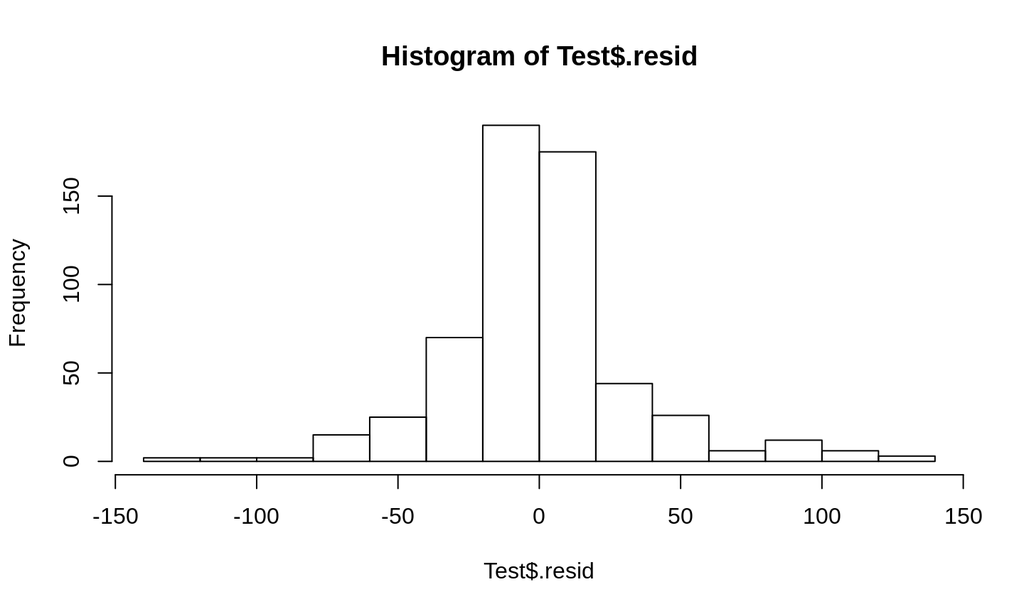

```r
Test <- augment(fit2)
hist(Test$.resid)
```

## Es la varianza constante?

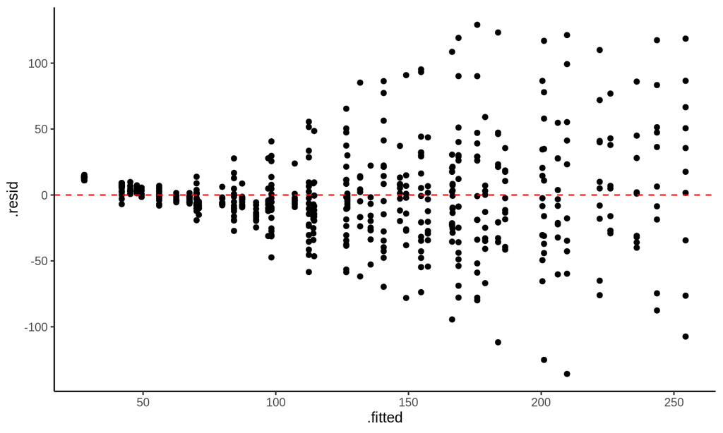

```r
ggplot(Test, aes(x = .fitted, y = .resid)) + geom_point() + theme_classic() + geom_hline(yintercept = 0,
    lty = 2, color = "red")
```

## GLMs

## Distribuciones

- Para entender GLM hay que entender distribuciones

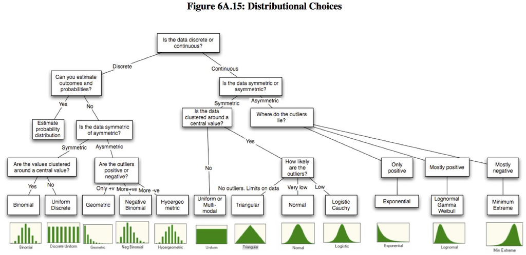

## Estructura de error

- **family =**
- gaussian (variable dependiente continua)
- binomial (variable dependiente 0 o 1)
- poisson (variable dependiente cuentas 1, 2 ,3 ,4 ,5)
- gamma (variable dependiente continua solo positiva)

## Modelo lineal generalizado

- Familia?
  - Gamma
  - respuesta (link = inverso)

\[\frac{1}{y} = \beta_1X_1 + C_0\]

## Modelo Gamma

```r
fit2g <- glm(weight ~ Time + Time:Diet, Gamma, data = ChickWeight)
```

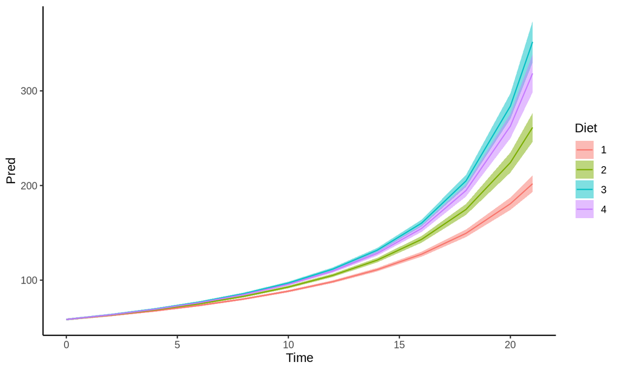

## Calculemos

- Nuevos datos

| term | estimate | std.error | statistic | p.value |
| --- | --- | --- | --- | --- |
| (Intercept) | 0.02 | 0 | 61.09 | 0 |
| Time | 0.00 | 0 | -31.21 | 0 |
| Time:Diet2 | 0.00 | 0 | -3.73 | 0 |
| Time:Diet3 | 0.00 | 0 | -7.78 | 0 |
| Time:Diet4 | 0.00 | 0 | -6.36 | 0 |

| Time | Diet |
| --- | --- |
| 3 | 1 |
| 4 | 4 |

## Modelo lineal generalizado

- Son los residuales normales?

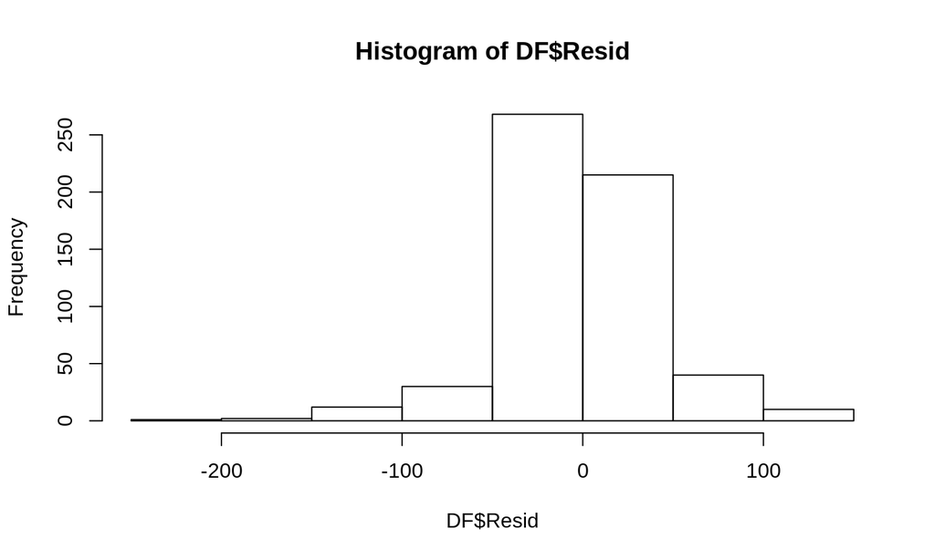

## Es la varianza constante?

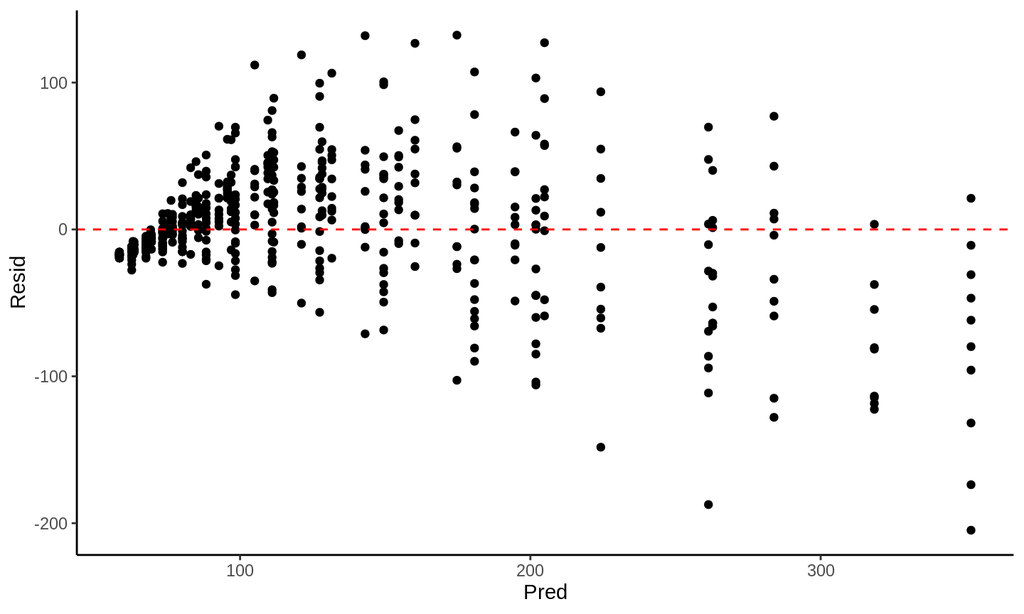

```r
ggplot(DF, aes(x = Pred, y = Resid)) + geom_point() + theme_classic() + geom_hline(yintercept = 0,
    lty = 2, color = "red")
```

## Modelo lineal generalizado

- Familia?
  - poisson
  - respuesta (link = log)

\[\log{y} = \beta_1X_1 + C_0\]

## Modelo Poisson

```r
fit2p <- glm(weight ~ Time + Time:Diet, poisson, data = ChickWeight)
```

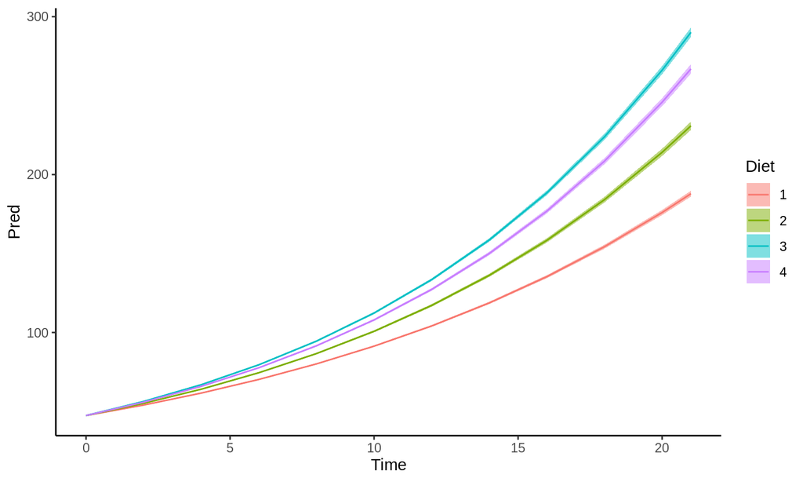

## Calculemos

- Nuevos datos

| term | estimate | std.error | statistic | p.value |
| --- | --- | --- | --- | --- |
| (Intercept) | 3.86 | 0.01 | 414.66 | 0 |
| Time | 0.07 | 0.00 | 90.82 | 0 |
| Time:Diet2 | 0.01 | 0.00 | 14.08 | 0 |
| Time:Diet3 | 0.02 | 0.00 | 31.37 | 0 |
| Time:Diet4 | 0.02 | 0.00 | 24.49 | 0 |

| Time | Diet |
| --- | --- |
| 3 | 1 |
| 4 | 4 |

## Modelo lineal generalizado

- Son los residuales normales?

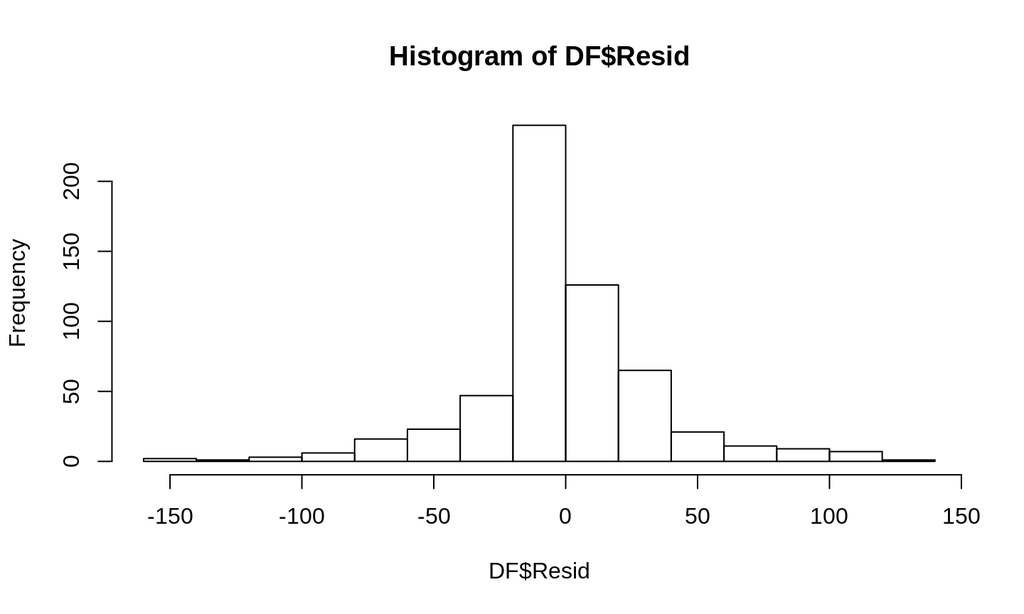

```r
hist(DF$Resid)
```

## Es la varianza constante?

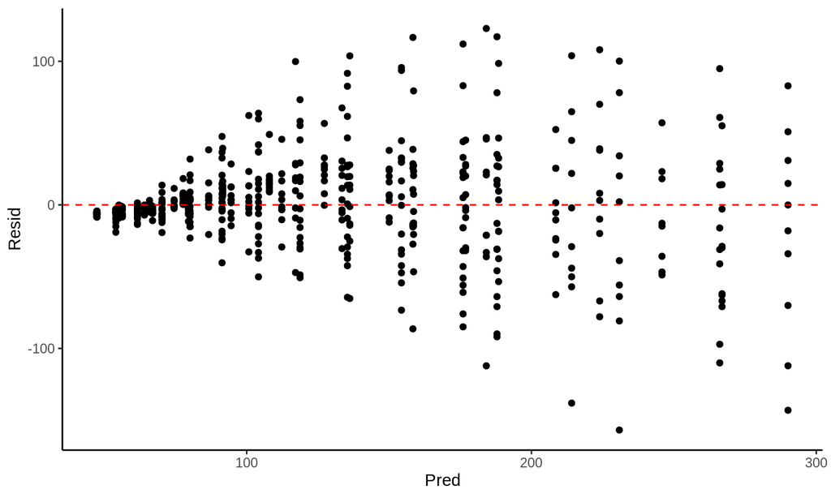

```r
ggplot(DF, aes(x = Pred, y = Resid)) + geom_point() + theme_classic() + geom_hline(yintercept = 0,
    lty = 2, color = "red")
```

## Modelo lineal generalizado

```r
train <- train <- read_csv("https://raw.githubusercontent.com/derek-corcoran-barrios/derek-corcoran-barrios.github.io/master/CursoMultiPres/Capitulo_3/train.csv") %>%
    filter(Embarked == "S")
```

| PassengerId | Survived | Pclass | Name | Sex | Age | SibSp | Parch | Ticket | Fare | Cabin | Embarked |
| --- | --- | --- | --- | --- | --- | --- | --- | --- | --- | --- | --- |
| 1 | 0 | 3 | Braund, Mr. Owen Harris | male | 22.00 | 1 | 0 | A/5 21171 | 7.250 | NA | S |
| 3 | 1 | 3 | Heikkinen, Miss. Laina | female | 26.00 | 0 | 0 | STON/O2. 3101282 | 7.925 | NA | S |
| 4 | 1 | 1 | Futrelle, Mrs. Jacques Heath (Lily May Peel) | female | 35.00 | 1 | 0 | 113803 | 53.100 | C123 | S |
| 5 | 0 | 3 | Allen, Mr. William Henry | male | 35.00 | 0 | 0 | 373450 | 8.050 | NA | S |
| 7 | 0 | 1 | McCarthy, Mr. Timothy J | male | 54.00 | 0 | 0 | 17463 | 51.862 | E46 | S |
| 8 | 0 | 3 | Palsson, Master. Gosta Leonard | male | 2.00 | 3 | 1 | 349909 | 21.075 | NA | S |
| 9 | 1 | 3 | Johnson, Mrs. Oscar W (Elisabeth Vilhelmina Berg) | female | 27.00 | 0 | 2 | 347742 | 11.133 | NA | S |
| 11 | 1 | 3 | Sandstrom, Miss. Marguerite Rut | female | 4.00 | 1 | 1 | PP 9549 | 16.700 | G6 | S |
| 12 | 1 | 1 | Bonnell, Miss. Elizabeth | female | 58.00 | 0 | 0 | 113783 | 26.550 | C103 | S |
| 13 | 0 | 3 | Saundercock, Mr. William Henry | male | 20.00 | 0 | 0 | A/5. 2151 | 8.050 | NA | S |
| 14 | 0 | 3 | Andersson, Mr. Anders Johan | male | 39.00 | 1 | 5 | 347082 | 31.275 | NA | S |
| 15 | 0 | 3 | Vestrom, Miss. Hulda Amanda Adolfina | female | 14.00 | 0 | 0 | 350406 | 7.854 | NA | S |
| 16 | 1 | 2 | Hewlett, Mrs. (Mary D Kingcome) | female | 55.00 | 0 | 0 | 248706 | 16.000 | NA | S |
| 18 | 1 | 2 | Williams, Mr. Charles Eugene | male | NA | 0 | 0 | 244373 | 13.000 | NA | S |
| 19 | 0 | 3 | Vander Planke, Mrs. Julius (Emelia Maria Vandemoortele) | female | 31.00 | 1 | 0 | 345763 | 18.000 | NA | S |
| 21 | 0 | 2 | Fynney, Mr. Joseph J | male | 35.00 | 0 | 0 | 239865 | 26.000 | NA | S |
| 22 | 1 | 2 | Beesley, Mr. Lawrence | male | 34.00 | 0 | 0 | 248698 | 13.000 | D56 | S |
| 24 | 1 | 1 | Sloper, Mr. William Thompson | male | 28.00 | 0 | 0 | 113788 | 35.500 | A6 | S |
| 25 | 0 | 3 | Palsson, Miss. Torborg Danira | female | 8.00 | 3 | 1 | 349909 | 21.075 | NA | S |
| 26 | 1 | 3 | Asplund, Mrs. Carl Oscar (Selma Augusta Emilia Johansson) | female | 38.00 | 1 | 5 | 347077 | 31.387 | NA | S |
| 28 | 0 | 1 | Fortune, Mr. Charles Alexander | male | 19.00 | 3 | 2 | 19950 | 263.000 | C23 C25 C27 | S |
| 30 | 0 | 3 | Todoroff, Mr. Lalio | male | NA | 0 | 0 | 349216 | 7.896 | NA | S |
| 34 | 0 | 2 | Wheadon, Mr. Edward H | male | 66.00 | 0 | 0 | C.A. 24579 | 10.500 | NA | S |
| 36 | 0 | 1 | Holverson, Mr. Alexander Oskar | male | 42.00 | 1 | 0 | 113789 | 52.000 | NA | S |
| 38 | 0 | 3 | Cann, Mr. Ernest Charles | male | 21.00 | 0 | 0 | A./5. 2152 | 8.050 | NA | S |
| 39 | 0 | 3 | Vander Planke, Miss. Augusta Maria | female | 18.00 | 2 | 0 | 345764 | 18.000 | NA | S |
| 41 | 0 | 3 | Ahlin, Mrs. Johan (Johanna Persdotter Larsson) | female | 40.00 | 1 | 0 | 7546 | 9.475 | NA | S |
| 42 | 0 | 2 | Turpin, Mrs. William John Robert (Dorothy Ann Wonnacott) | female | 27.00 | 1 | 0 | 11668 | 21.000 | NA | S |
| 46 | 0 | 3 | Rogers, Mr. William John | male | NA | 0 | 0 | S.C./A.4. 23567 | 8.050 | NA | S |
| 50 | 0 | 3 | Arnold-Franchi, Mrs. Josef (Josefine Franchi) | female | 18.00 | 1 | 0 | 349237 | 17.800 | NA | S |

[output cut: 614 more lines]

## Modelo lineal generalizado

- Familia?
  - Binomial
  - respuesta (link = logit)

\[log{\frac{p}{1-p}} = \beta_1X_1 + C_0\]

## Modelo lineal generalizado (familia: binomial)

```r
FitBin <- glm(Survived ~ Fare + Sex, data = train)
```

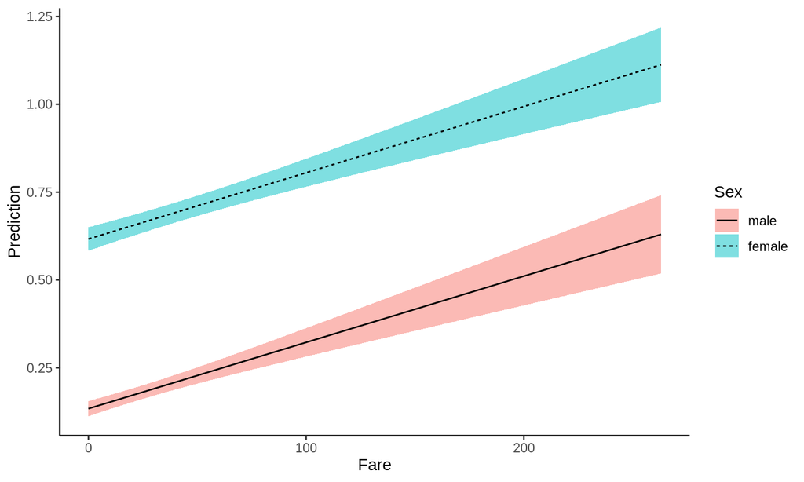

## Modelo lineal generalizado (familia: binomial)

```r
FitBin <- glm(Survived ~ Fare + Sex, data = train)
```

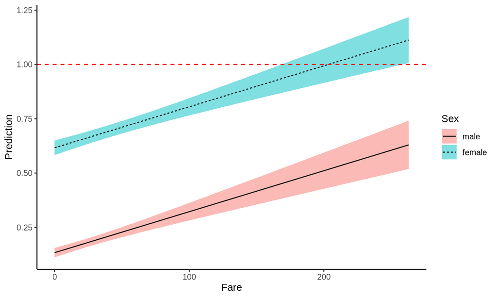

## Modelo lineal generalizado (familia: binomial)

```r
FitBin2 <- glm(Survived ~ Fare * Sex, data = train, family = binomial)
```

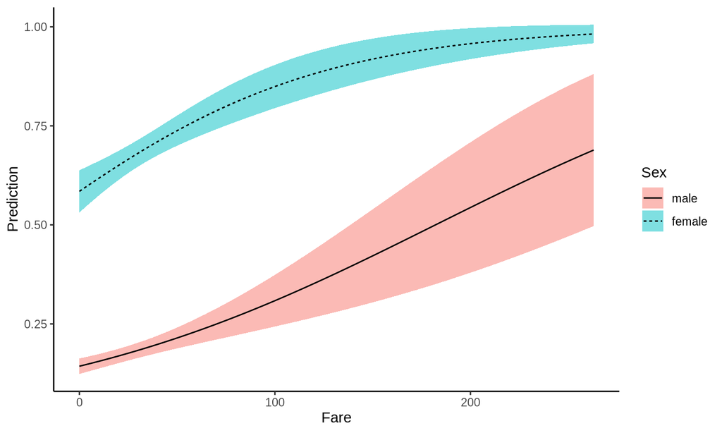

## Modelo lineal generalizado (familia: binomial)

| term | estimate | std.error | statistic | p.value |
| --- | --- | --- | --- | --- |
| (Intercept) | 0.34 | 0.22 | 1.56 | 0.12 |
| Fare | 0.01 | 0.01 | 2.51 | 0.01 |
| Sexmale | -2.13 | 0.27 | -7.89 | 0.00 |
| Fare:Sexmale | 0.00 | 0.01 | -0.61 | 0.54 |

| null.deviance | df.null | logLik | AIC | BIC | deviance | df.residual |
| --- | --- | --- | --- | --- | --- | --- |
| 823.03 | 643 | -321.81 | 651.62 | 669.49 | 643.62 | 640 |

\(R^2\): 0.3370364

## Modelo lineal generalizado (familia: binomial)

```r
FitBin2 <- glm(Survived ~ Fare * Sex, data = train, family = binomial())
```

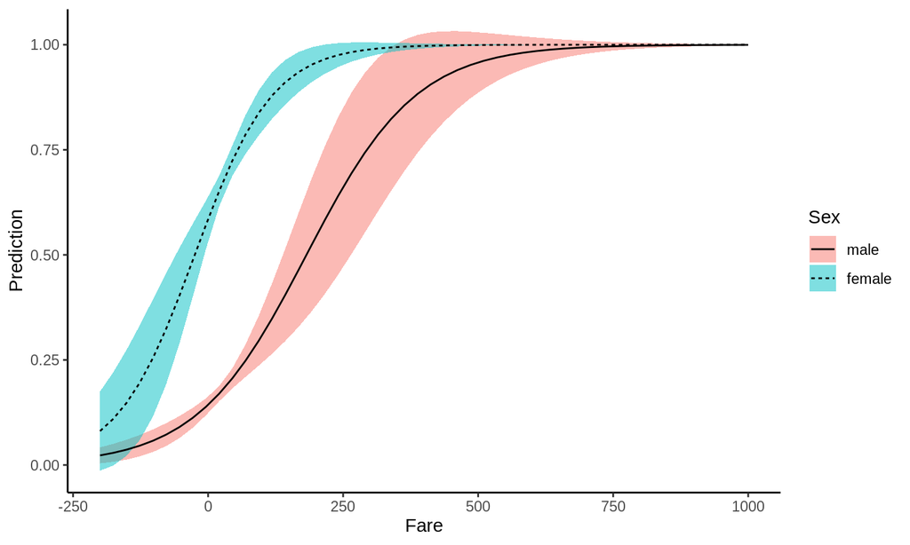

## Función link

- Actua sobre \(Y\)
- family Gaussian, link = identidad
- family Gamma, link = inverso
- family poisson, link = log
- family binomial, link = logit

\[Logit = log{\frac{p}{1-p}}\]

## Función link

| Valor | Identidad | Inverso | Log | logit |
| --- | --- | --- | --- | --- |
| -1.0 | -1.0 | -1.0000000 | NaN | NaN |
| -0.8 | -0.8 | -1.2500000 | NaN | NaN |
| 0.1 | 0.1 | 10.0000000 | -2.3025851 | -2.197225 |
| 0.2 | 0.2 | 5.0000000 | -1.6094379 | -1.386294 |
| 0.5 | 0.5 | 2.0000000 | -0.6931472 | 0.000000 |
| 0.8 | 0.8 | 1.2500000 | -0.2231436 | 1.386294 |
| 1.0 | 1.0 | 1.0000000 | 0.0000000 | Inf |
| 2.0 | 2.0 | 0.5000000 | 0.6931472 | NaN |
| 2.3 | 2.3 | 0.4347826 | 0.8329091 | NaN |

## Función link

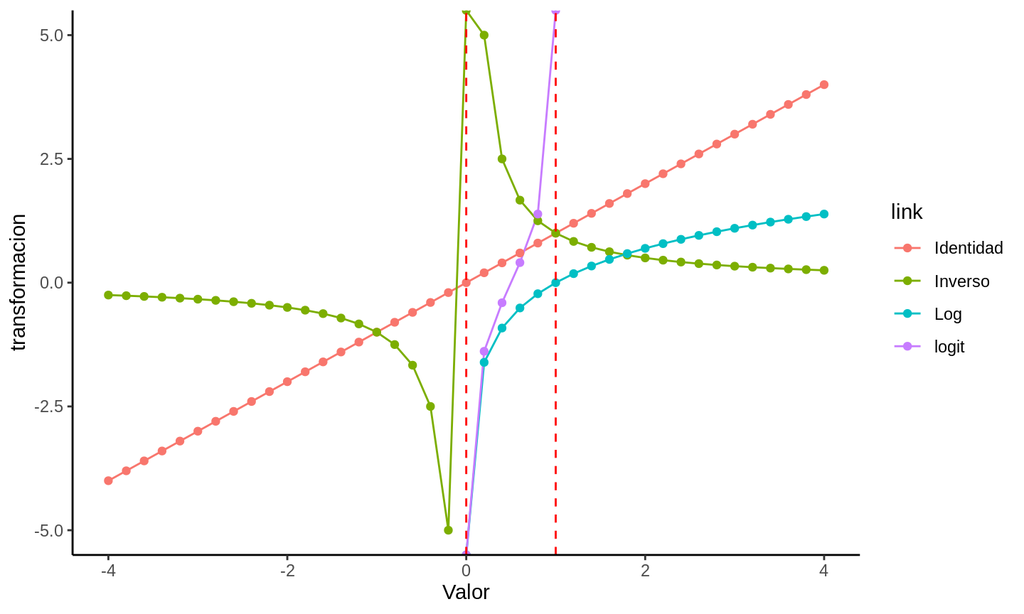

## Ajuste

Pseudo \(R^2\)